# STAT656_Project

Moein-Samira-Homa

10/8/2020

#Read the Data We first read the data includes covid data, ICU data, demographic data, geographic data, and health data.

```r
setwd("~/R/final project")
rm(list = ls())
final_data = fread("Final-Covid.csv")
```

#Plot Missing Data

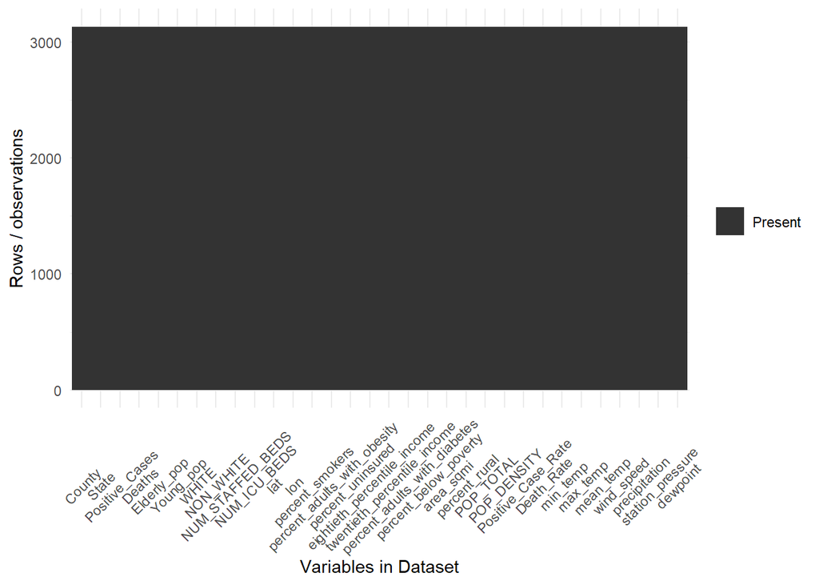

```r
ggplot_missing <- function(x){
  require(reshape2)
  require(ggplot2)
  x %>%
    is.na %>%
    melt %>%
    ggplot(data = .,
           aes(x = Var2,
               y = Var1)) +
    geom_raster(aes(fill = value)) +
    scale_fill_grey(name = "",
                    labels = c("Present","Missing")) +
    theme_minimal() +
    theme(axis.text.x  = element_text(angle=45, vjust=0.5)) +
    labs(x = "Variables in Dataset",
         y = "Rows / observations")
}

ggplot_missing(final_data)
```

```r
#Calculate the NAN counts and NAN percentage for each column

colMeans(is.na(final_data))
```

```
##                       County                        State
##                            0                            0
##               Positive_Cases                       Deaths
##                            0                            0
##                  Elderly_pop                    Young_pop
##                            0                            0
##                        WHITE                    NON_WHITE
##                            0                            0
##             NUM_STAFFED_BEDS                 NUM_ICU_BEDS
##                            0                            0
##                          lat                          lon
##                            0                            0
##              percent_smokers  percent_adults_with_obesity
##                            0                            0
##            percent_uninsured  eightieth_percentile_income
##                            0                            0
##  twentieth_percentile_income percent_adults_with_diabetes
##                            0                            0
##        percent_below_poverty                    area_sqmi
##                            0                            0
##                percent_rural                    POP_TOTAL
##                            0                            0
##                  POP_DENSITY           Positive_Case_Rate
##                            0                            0
##                   Death_Rate                     min_temp
##                            0                            0
##                     max_temp                    mean_temp
##                            0                            0
##                   wind_speed                precipitation
##                            0                            0
##             station_pressure                     dewpoint
##                            0                            0
```

#Normalize the Covid data to be prepared for the clustering analysis

```r
final_data$Positive_Case_Rate_NORM = scale(final_data$Positive_Case_Rate)
final_data$Death_Rate_NORM = scale(final_data$Death_Rate)
```

#Clustering analysis with K=3 and K=5

```r
clustered_data_3 = kmeans(cbind(final_data$Positive_Case_Rate_NORM, final_data$Death_Rate_NORM), 3, iter.max = 10, nstart = 1)
clustered_data_5 = kmeans(cbind(final_data$Positive_Case_Rate_NORM, final_data$Death_Rate_NORM), 5, iter.max = 10, nstart = 1)

final_data$cluster_3 = clustered_data_3$cluster
final_data$cluster_5 = clustered_data_5$cluster
```

#Visualize the clustering results

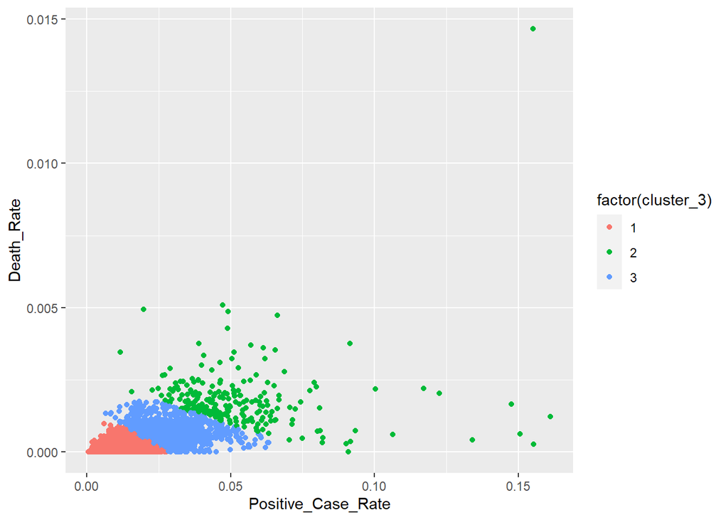

```r
ggplot(data = final_data, aes(x=Positive_Case_Rate, y=Death_Rate, colour = factor(cluster_3))) + geom_point()
```

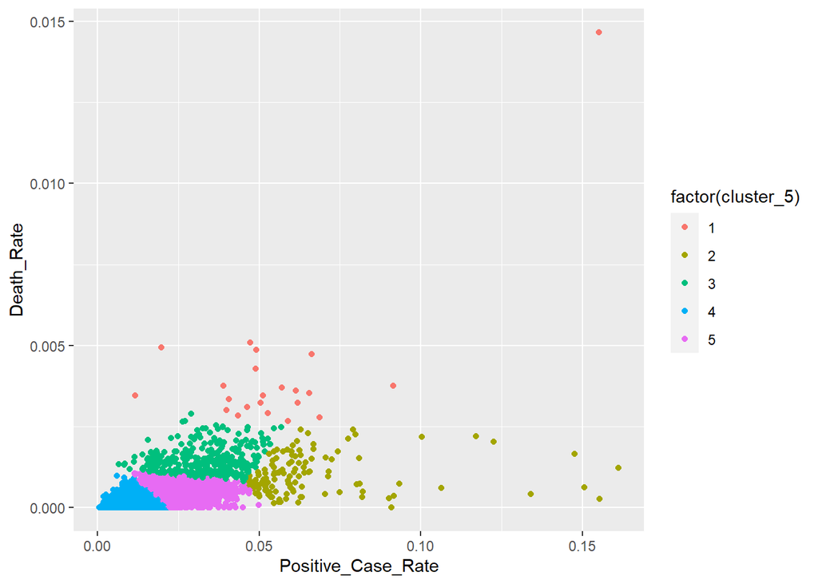

```r
ggplot(data = final_data, aes(x=Positive_Case_Rate, y=Death_Rate, colour = factor(cluster_5))) + geom_point()
```

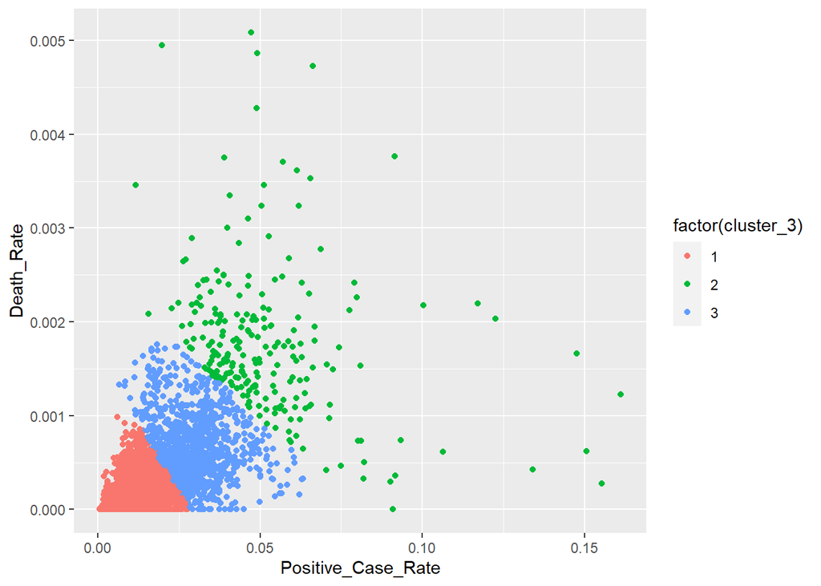

```r
final_data_wo_ny <- final_data %>% filter(County != "New York")

ggplot(data = final_data_wo_ny, aes(x=Positive_Case_Rate, y=Death_Rate, colour = factor(cluster_3))) + geom_point()
```

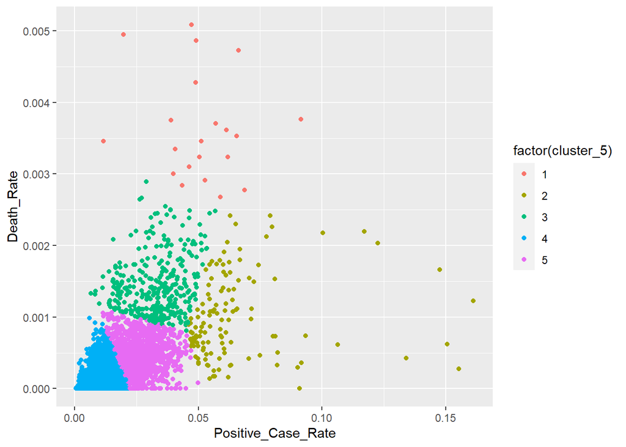

```r
ggplot(data = final_data_wo_ny, aes(x=Positive_Case_Rate, y=Death_Rate, colour = factor(cluster_5))) + geom_point()
```

#check if Newyork is an outlier based on the Positive case rate and death case rate

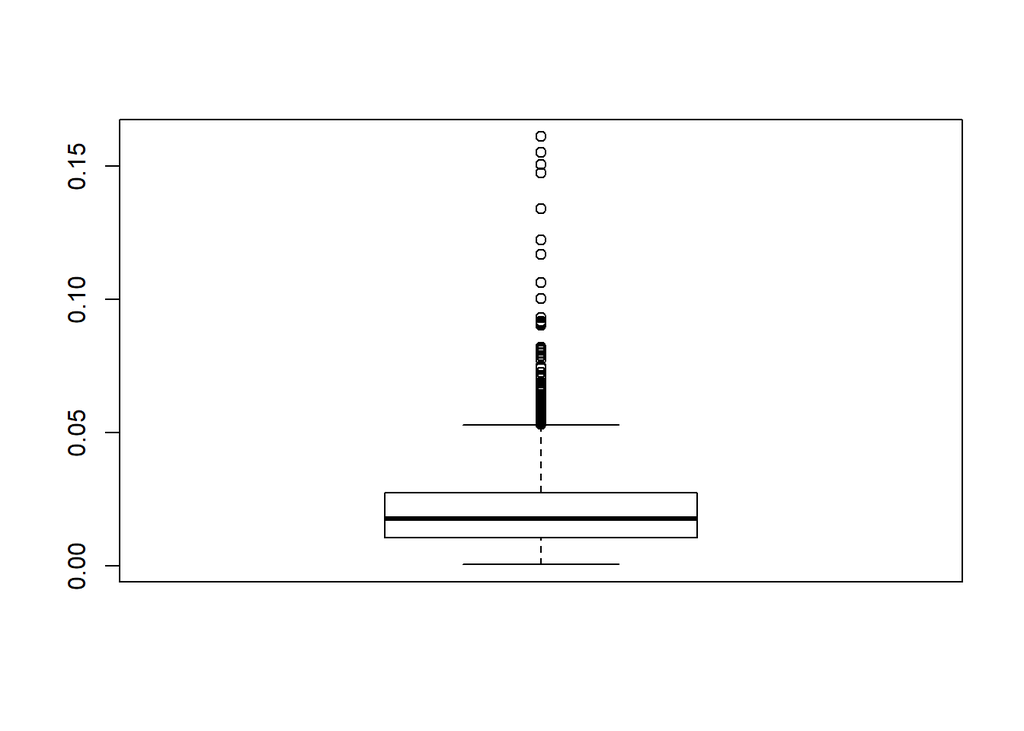

```r
boxplot(final_data$Positive_Case_Rate)
```

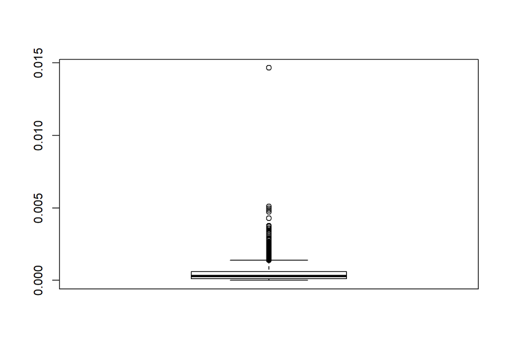

```r
boxplot(final_data$Death_Rate)
```

# Normalizing Data

```r
names(final_data)
```

```
##  [1] "County"                       "State"
##  [3] "Positive_Cases"               "Deaths"
##  [5] "Elderly_pop"                  "Young_pop"
##  [7] "WHITE"                        "NON_WHITE"
##  [9] "NUM_STAFFED_BEDS"             "NUM_ICU_BEDS"
## [11] "lat"                          "lon"
## [13] "percent_smokers"              "percent_adults_with_obesity"
## [15] "percent_uninsured"            "eightieth_percentile_income"
## [17] "twentieth_percentile_income"  "percent_adults_with_diabetes"
## [19] "percent_below_poverty"        "area_sqmi"
## [21] "percent_rural"                "POP_TOTAL"
## [23] "POP_DENSITY"                  "Positive_Case_Rate"
## [25] "Death_Rate"                   "min_temp"
## [27] "max_temp"                     "mean_temp"
## [29] "wind_speed"                   "precipitation"
## [31] "station_pressure"             "dewpoint"
## [33] "Positive_Case_Rate_NORM"      "Death_Rate_NORM"
## [35] "cluster_3"                    "cluster_5"
```

```r
X <- model.matrix(Death_Rate ~ Elderly_pop+ Young_pop + WHITE+ NON_WHITE + NUM_STAFFED_BEDS + NUM_ICU_BEDS +lat +lon + percent_smokers + percent_adults_with_obesity + percent_uninsured + eightieth_percentile_income + twentieth_percentile_income + percent_adults_with_diabetes + percent_below_poverty + area_sqmi +percent_rural +POP_DENSITY+ min_temp + max_temp + mean_temp+ wind_speed +precipitation + station_pressure + dewpoint, data=final_data) [,-1]

Y <- final_data$ Positive_Case_Rate
Y2 <- final_data$ Death_Rate

X= scale(X, center = TRUE, scale = TRUE)
Y= scale(Y, center = TRUE, scale = TRUE)
Y2= scale(Y2, center = TRUE, scale = TRUE)
```

#use multiple regression for model selection for Positive case rate as Y variable

```r
Lm_caserate<- lm (Y ~ X)

summary (Lm_caserate)
```

```
##
## Call:
## lm(formula = Y ~ X)
##
## Residuals:
##     Min      1Q  Median      3Q     Max
## -2.3461 -0.5087 -0.1199  0.3413  8.7924
##
## Coefficients:
##                                 Estimate Std. Error t value Pr(>|t|)
## (Intercept)                    4.715e-16  1.492e-02   0.000 1.000000
## XElderly_pop                  -3.666e-01  2.245e-01  -1.633 0.102507
## XYoung_pop                    -1.119e-01  1.235e+00  -0.091 0.927816
## XWHITE                         3.489e-01  1.031e+00   0.338 0.735214
## XNON_WHITE                     2.972e-02  4.407e-01   0.067 0.946235
## XNUM_STAFFED_BEDS              1.110e-01  8.769e-02   1.265 0.205868
## XNUM_ICU_BEDS                 -2.960e-02  7.070e-02  -0.419 0.675510
## Xlat                          -5.907e-02  4.055e-02  -1.457 0.145324
## Xlon                          -1.097e-01  2.332e-02  -4.703 2.67e-06 ***
## Xpercent_smokers               8.120e-02  2.571e-02   3.159 0.001599 **
## Xpercent_adults_with_obesity   8.643e-02  1.968e-02   4.391 1.17e-05 ***
## Xpercent_uninsured             1.349e-01  2.011e-02   6.710 2.30e-11 ***
## Xeightieth_percentile_income   9.790e-04  3.610e-02   0.027 0.978363
## Xtwentieth_percentile_income   6.434e-02  3.991e-02   1.612 0.106995
## Xpercent_adults_with_diabetes -4.330e-02  1.954e-02  -2.216 0.026753 *
## Xpercent_below_poverty         1.949e-01  3.141e-02   6.206 6.16e-10 ***
## Xarea_sqmi                    -3.813e-02  1.752e-02  -2.176 0.029612 *
## Xpercent_rural                -9.442e-02  1.906e-02  -4.954 7.67e-07 ***
## XPOP_DENSITY                   1.630e-01  1.750e-02   9.312  < 2e-16 ***
## Xmin_temp                     -4.711e-01  6.778e-02  -6.951 4.41e-12 ***
## Xmax_temp                     -1.326e-01  3.648e-02  -3.634 0.000284 ***
## Xmean_temp                     4.853e-01  8.238e-02   5.891 4.26e-09 ***
## Xwind_speed                    9.612e-02  1.886e-02   5.097 3.66e-07 ***
## Xprecipitation                 4.738e-02  2.419e-02   1.959 0.050259 .
## Xstation_pressure             -1.566e-01  1.922e-02  -8.151 5.19e-16 ***
## Xdewpoint                      2.791e-01  4.226e-02   6.603 4.73e-11 ***
## ---
## Signif. codes:  0 '***' 0.001 '**' 0.01 '*' 0.05 '.' 0.1 ' ' 1
##
## Residual standard error: 0.835 on 3105 degrees of freedom
## Multiple R-squared:  0.3083, Adjusted R-squared:  0.3027
## F-statistic: 55.35 on 25 and 3105 DF,  p-value: < 2.2e-16
```

#Multiple regression with death rate as Y variable

```r
Lm_deathrate<- lm (Y2 ~ X)

summary (Lm_deathrate)
```

```
##
## Call:
## lm(formula = Y2 ~ X)
##
## Residuals:
##     Min      1Q  Median      3Q     Max
## -5.0771 -0.4316 -0.1370  0.2323  6.9670
##
## Coefficients:
##                                 Estimate Std. Error t value Pr(>|t|)
## (Intercept)                    4.860e-16  1.392e-02   0.000 1.000000
## XElderly_pop                  -1.304e-01  2.094e-01  -0.623 0.533446
## XYoung_pop                    -1.524e+00  1.152e+00  -1.323 0.185960
## XWHITE                         1.256e+00  9.621e-01   1.305 0.191973
## XNON_WHITE                     3.808e-01  4.111e-01   0.926 0.354307
## XNUM_STAFFED_BEDS              1.807e-01  8.179e-02   2.209 0.027270 *
## XNUM_ICU_BEDS                 -1.772e-01  6.594e-02  -2.687 0.007242 **
## Xlat                          -9.262e-02  3.783e-02  -2.448 0.014403 *
## Xlon                           9.254e-02  2.175e-02   4.254 2.16e-05 ***
## Xpercent_smokers              -7.853e-02  2.398e-02  -3.275 0.001067 **
## Xpercent_adults_with_obesity   7.510e-02  1.836e-02   4.090 4.42e-05 ***
## Xpercent_uninsured             7.010e-02  1.876e-02   3.737 0.000189 ***
## Xeightieth_percentile_income   9.626e-02  3.367e-02   2.859 0.004277 **
## Xtwentieth_percentile_income  -8.595e-02  3.722e-02  -2.309 0.021009 *
## Xpercent_adults_with_diabetes  3.044e-02  1.822e-02   1.670 0.094956 .
## Xpercent_below_poverty         2.203e-01  2.930e-02   7.517 7.27e-14 ***
## Xarea_sqmi                     2.444e-02  1.634e-02   1.496 0.134795
## Xpercent_rural                 7.271e-03  1.778e-02   0.409 0.682570
## XPOP_DENSITY                   4.207e-01  1.633e-02  25.769  < 2e-16 ***
## Xmin_temp                     -2.350e-01  6.322e-02  -3.716 0.000206 ***
## Xmax_temp                     -8.571e-02  3.402e-02  -2.519 0.011817 *
## Xmean_temp                     3.206e-01  7.685e-02   4.172 3.11e-05 ***
## Xwind_speed                    2.544e-02  1.759e-02   1.446 0.148141
## Xprecipitation                -4.002e-02  2.257e-02  -1.773 0.076269 .
## Xstation_pressure             -1.950e-01  1.793e-02 -10.879  < 2e-16 ***
## Xdewpoint                      4.780e-02  3.942e-02   1.213 0.225389
## ---
## Signif. codes:  0 '***' 0.001 '**' 0.01 '*' 0.05 '.' 0.1 ' ' 1
##
## Residual standard error: 0.7789 on 3105 degrees of freedom
## Multiple R-squared:  0.3981, Adjusted R-squared:  0.3933
## F-statistic: 82.16 on 25 and 3105 DF,  p-value: < 2.2e-16
```